# Dahn-Young Dong Final Project

#### 2.3 Verify the quality of the filtered dataset

```r
site.depth2 <- Query(snps_fil_ldF, "site-mean-depth")
```

```
##
## VCFtools - 0.1.17
## (C) Adam Auton and Anthony Marcketta 2009
##
## Parameters as interpreted:
##  --vcf /var/folders/fg/x245ssxd4w76gcsndt4lhgxr0000gp/T//RtmpIGEckf/vcfLink_filef2ab18865d8a
##  --site-mean-depth
##  --stdout
##
## After filtering, kept 16 out of 16 Individuals
## Outputting Depth for Each Site
## After filtering, kept 3658 out of a possible 3658 Sites
## Run Time = 0.00 seconds
```

```r
HWE2 <- Query(snps_fil_ldF, type="hardy")
```

```
##
## VCFtools - 0.1.17
## (C) Adam Auton and Anthony Marcketta 2009
##
## Parameters as interpreted:
##  --vcf /var/folders/fg/x245ssxd4w76gcsndt4lhgxr0000gp/T//RtmpIGEckf/vcfLink_filef2ab18865d8a
##  --hardy
##  --stdout
##
## After filtering, kept 16 out of 16 Individuals
## Outputting HWE statistics (but only for biallelic loci)
## After filtering, kept 3658 out of a possible 3658 Sites
## Run Time = 0.00 seconds
```

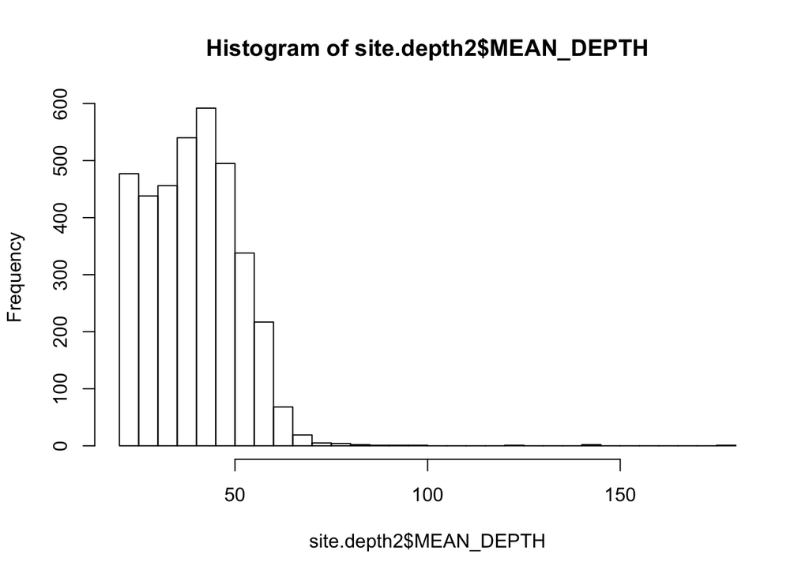

```r
hist(site.depth2$MEAN_DEPTH, breaks=50)
```

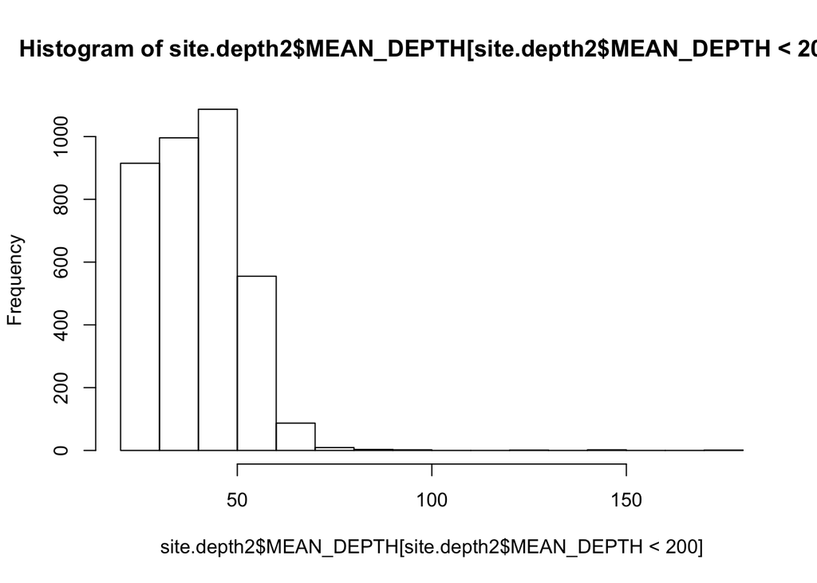

```r
hist(site.depth2$MEAN_DEPTH[site.depth2$MEAN_DEPTH <200])
```

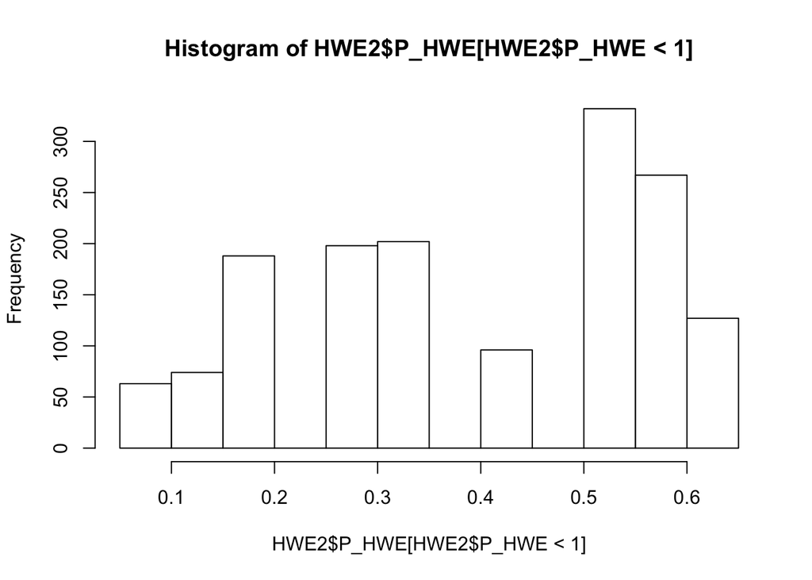

```r
hist(HWE2$P_HWE[HWE2$P_HWE< 1]) # all the SNPs with <0.05 p values are excluded already. good sign
```

```r
#Verify the real missing data per individual:
Missing_ind <- apply(GenotypeMatrix(snps_fil_ldF),1, function(x) sum(x<0)/length(x)*100)
```

```
##
## VCFtools - 0.1.17
## (C) Adam Auton and Anthony Marcketta 2009
##
## Parameters as interpreted:
##  --vcf /var/folders/fg/x245ssxd4w76gcsndt4lhgxr0000gp/T//RtmpIGEckf/vcfLink_filef2ab27b2d212
##  --012
##  --out /var/folders/fg/x245ssxd4w76gcsndt4lhgxr0000gp/T//RtmpIGEckf/vcfLink_filef2ab4a1ad570
##
## After filtering, kept 16 out of 16 Individuals
## Writing 012 matrix files ... Done.
## After filtering, kept 3658 out of a possible 3658 Sites
## Run Time = 0.00 seconds
```

```r
summary(Missing_ind) ## no more missing individuals
```

```
##    Min. 1st Qu.  Median    Mean 3rd Qu.    Max.
##       0       0       0       0       0       0
```

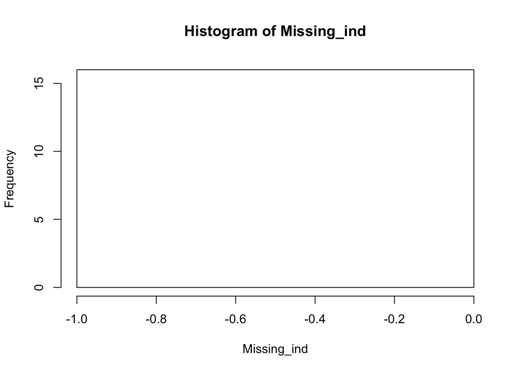

```r
hist(Missing_ind)
```

```r
#Verify the real missing data per locus:
Missing <- apply(GenotypeMatrix(snps_fil_ldF), 2, function(x) sum(x < 0)/length(x)*100) ## Actual percentage of missing data
```

```
##
## VCFtools - 0.1.17
## (C) Adam Auton and Anthony Marcketta 2009
##
## Parameters as interpreted:
##  --vcf /var/folders/fg/x245ssxd4w76gcsndt4lhgxr0000gp/T//RtmpIGEckf/vcfLink_filef2ab54953e13
##  --012
##  --out /var/folders/fg/x245ssxd4w76gcsndt4lhgxr0000gp/T//RtmpIGEckf/vcfLink_filef2ab2334a273
##
## After filtering, kept 16 out of 16 Individuals
## Writing 012 matrix files ... Done.
## After filtering, kept 3658 out of a possible 3658 Sites
## Run Time = 0.00 seconds
```

```r
summary(Missing) # no more missing locus- good sign for successful filtering above.
```

```
##    Min. 1st Qu.  Median    Mean 3rd Qu.    Max.
##       0       0       0       0       0       0
```

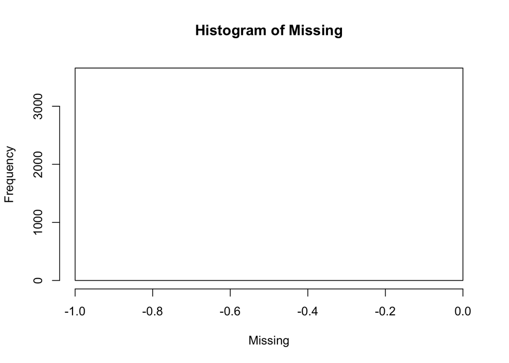

```r
hist(Missing)
```

```r
VCFsummary(snps_unind) #16 individuals and 18077 SNPs.
```

```
## 16 individuals and 18077 SNPs.
```

```r
VCFsummary(snps_fil_ldF) ##16 individuals and 3658 SNPs. # would this change the resulting ancestry significantly? I used to have only 100 SNPs left
```

```
## 16 individuals and 3658 SNPs.
```

### 3. TESS3 inference of Spatial Population Genetic Structure (https://bcm-uga.github.io/TESS3_encho_sen/articles/main-vignette.html)

#### 3.1. Input files/objects for TESS analyses

```r
#Load the .VCF file with only neutral SNPs:
snps <- vcfLink(paste0("vcf/", project_name,"_filtered_neutral_partial.vcf"), overwriteID=T)
VCFsummary(snps) ##16 individuals and 3658 SNPs.
```

```
## 16 individuals and 3658 SNPs.
```

```r
#Create a Genotype matrix
genotypes <- GenotypeMatrix(snps) # only returns biallelic
```

```
##
## VCFtools - 0.1.17
## (C) Adam Auton and Anthony Marcketta 2009
##
## Parameters as interpreted:
##  --vcf /var/folders/fg/x245ssxd4w76gcsndt4lhgxr0000gp/T//RtmpIGEckf/vcfLink_filef2ab466bd9fd
##  --012
##  --out /var/folders/fg/x245ssxd4w76gcsndt4lhgxr0000gp/T//RtmpIGEckf/vcfLink_filef2ab3ddc3e05
##
## After filtering, kept 16 out of 16 Individuals
## Writing 012 matrix files ... Done.
## After filtering, kept 3658 out of a possible 3658 Sites
## Run Time = 0.00 seconds
```

```r
genotypes[1:16, 3000:3010] ## -1 is missing # should have no missing because I filtered out everything and did quality check.
```

```
##                         snp3000 snp3001 snp3002 snp3003 snp3004 snp3005 snp3006
## YMF2018_009_S25001.trim       0       1       1       1       1       1       0
## YMF2018_011_S27001.trim       0       0       0       0       0       0       2
## YMF2018_012_S29001.trim       1       0       0       1       1       2       1
## YMF2018_013_S31001.trim       0       0       1       0       0       0       2
## YMF2018_017_S33001.trim       1       0       0       0       0       2       0
## YMF2018_018_S35001.trim       1       1       1       1       2       0       1
## YMF2018_019_S37001.trim       1       1       2       2       1       1       0
## YMF2018_022_S39001.trim       1       1       2       2       1       0       1
## YMF2018_025_S26001.trim       2       2       1       0       1       0       1
## YMF2018_028_S28001.trim       0       1       0       2       0       1       1
## YMF2018_030_S30001.trim       0       2       1       2       1       0       0
## YMF2018_032_S32001.trim       1       1       1       0       0       1       1
## YMF2018_033_S34001.trim       0       0       1       1       0       2       1
## YMF2018_036_S36001.trim       0       0       0       0       0       0       1
## YMF2018_037_S38001.trim       0       1       0       0       1       0       2
## YMF2018_039_S40001.trim       2       2       0       0       2       1       0
##                         snp3007 snp3008 snp3009 snp3010
## YMF2018_009_S25001.trim       1       1       0       2
## YMF2018_011_S27001.trim       1       1       0       0
## YMF2018_012_S29001.trim       1       1       0       1
## YMF2018_013_S31001.trim       1       1       0       1
## YMF2018_017_S33001.trim       1       0       1       1
## YMF2018_018_S35001.trim       0       0       1       1
## YMF2018_019_S37001.trim       0       2       0       1
## YMF2018_022_S39001.trim       1       1       2       1
## YMF2018_025_S26001.trim       0       0       0       0
## YMF2018_028_S28001.trim       1       0       0       0
## YMF2018_030_S30001.trim       1       0       1       0
## YMF2018_032_S32001.trim       2       0       0       0
## YMF2018_033_S34001.trim       2       1       0       0
## YMF2018_036_S36001.trim       2       1       1       1
## YMF2018_037_S38001.trim       0       1       0       0
## YMF2018_039_S40001.trim       2       0       1       2
```

```r
#Create a Matrix with long and lat
coordinates <- snps@meta[,4:5] #added pond ID here
class(coordinates)
```

```
## [1] "data.frame"
```

```r
coordinates <- data.matrix(coordinates, rownames.force = NA) #force all data type into numeric
class(coordinates)
```

```
## [1] "matrix"
```

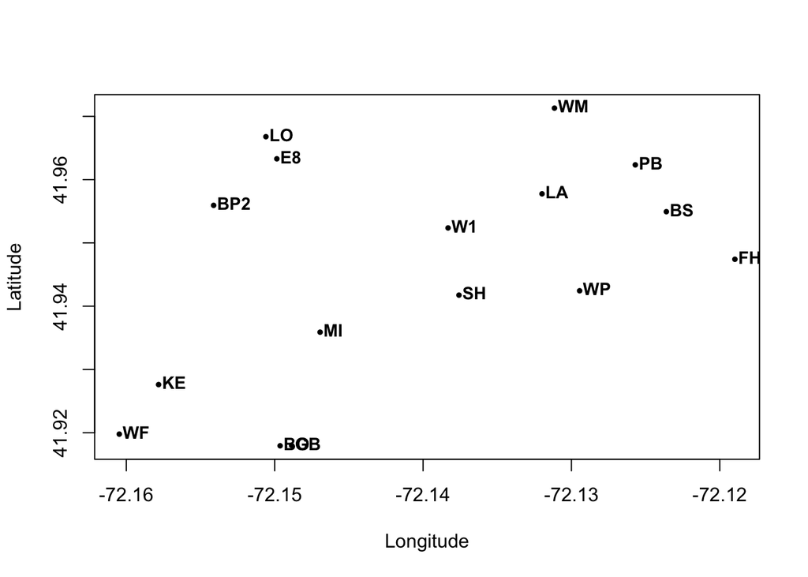

```r
#verify the coords
plot(coordinates, pch = 19, cex = .5, xlab = "Longitude", ylab = "Latitude")
text(coordinates, labels=snps@meta[,3],data=snps@meta, cex=0.9, font=2, pos = 4, offset = 0.15)
```

#### 3.2 Running the TESS3R function

Population genetic structure analysis includes three main steps:

1.running one or more inference algorithms, 2.choosing the number of ancestral populations or genetic clusters, 3.showing bar-plots of ancestry coefficients or displaying them on geographic maps.

```r
#Customize parameters for the run
K = c(1:2) # set the number of K to be tested
ploidy = 2 # species ploidy
CPU = 4 #Number of cores for run in parallel
```

```r
#Estimate ancestry coefficients
#set.seed(1)
tess3.ls <- tess3(X = genotypes, coord = coordinates, K = K,
                   method = "projected.ls", ploidy = ploidy, openMP.core.num = CPU)
```

```
## == Computing spectral decomposition of graph laplacian matrix: done
## ==Main loop with 4 threads: done
## == Computing spectral decomposition of graph laplacian matrix: done
## ==Main loop with 4 threads: done
```

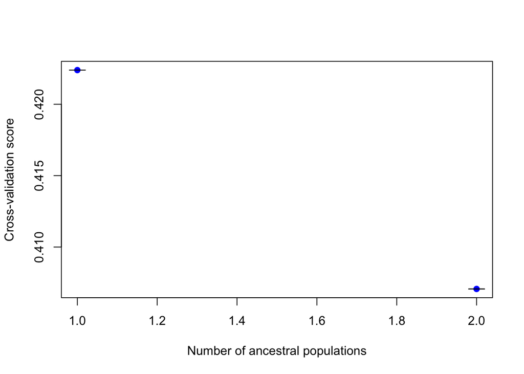

```r
#to choose best K, generates a plot for root mean-squared errors computed on a subset of loci used for cross-validation.
plot(tess3.ls, pch = 19, col = "blue",
     xlab = "Number of ancestral populations",
     ylab = "Cross-validation score")
```

```r
#Smaller values of the cross-validation criterion mean better runs. The best choice for the K value is when the cross-validation curve exhibits a plateau or starts increasing.

# My scores keep decreasing as K increases, so the more K, the better. So my decision here is fairly arbitrary. It largely depends on visual assessment of how much the ancestry corresponds to the elevation and river systems.
```

## Results

### 4. Visualizing ancestry and with geography

#### 4.1 Ancestry Matrix in barplot of individuals

```r
# retrieve tess3 Q matrix for K = 2 clusters
#q.matrix <- qmatrix(tess3.ls, K = 2)
```

```r
# plot
#pdf(file = "./Results_TESS/TESS_Ancestry_K?.pdf", width = 4, height = 4)

#my.colors <- c("red","yellow","green","purple","turquoise", "blue")
#my.palette <- CreatePalette(my.colors, 6)
#barplot(q.matrix, border = T, space = 0, main = "Ancestry matrix", xlab = "Individuals", ylab = "Ancestry proportions", col.palette = my.palette) -> bp
#axis(1, at = 0.5:nrow(q.matrix), labels = snps@meta[,3][bp$order], las = 3, cex.axis = 1)

#dev.off()
```

#### 4.2 Ancestry coefficients as spatial interpolations

```r
#prepping objects to plot
#DEM_base <- readRDS("./maps/rasters/DEM_base.rds")
#ext = extent(-72.16100, -72.11800, 41.91700, 41.97200)
#river <- raster::shapefile("./maps/vectors/rivers.shp")
#river <- spTransform(river, DEM_base@crs)
#river <- crop(river, ext)
```

```r
#display interpolated values of ancestry coefficients on geographic maps

#pdf("./Results_TESS/TESS_MAP_K?.pdf")

#par(mfrow = c(1, 2))
#par(mar = c(4, 3, 2, 5))

#plot(x = q.matrix, coord = coordinates, method = "map.max", interpol = FieldsKrigModel(10),
    # main = "Ancestry coefficients",
    # xlab = "Longitude", ylab = "Latitude",cex.lab=1,
    # resolution = c(700,700), cex = 1,
    # col.palette = my.palette)
#text(coordinates, labels=snps@meta[,3],data=snps@meta, cex=0.9, font=2, pos = 4, offset = 0.3)

#with geo and elevation (I personally stitched and wrangled the DEM file using geospatial tools during the summer)
#plot(DEM_base, col = gray.colors(20, start = 0, end = 1), ext = ext, main = "Elevation and Major rivers", cex.lab=1, cex = 1)
#points(snps@meta$longitude, snps@meta$latitude, pch = 20, col = "red")
#text(coordinates, labels=snps@meta[,3],data=snps@meta, cex=0.9, font=2, pos = 4, offset = 0.3, col = "red")
#plot(river, add = TRUE, ext = ext)
#dev.off()
```

#### 4.3 Comparing results of different K values (might not be useful)

Due to the stochastic nature of tess3 function that generated the matrices for these graphs (likely due to small individual sample size and number of loci), the root mean square errors is huge. And each iteration produces different results. See 5.5. So the results might not be interpretable. Based on Caye et al. 2016 Figure 1, the function becomes more reliable when sample size is larger then 200 and loci larger than 50000. Where my dataset is a magnitude smaller than the recommended.

The assignment of colors among different K values are random.

```r
# root mean squared error
tess3.ls[[2]]$rmse
```

```
## [1] 0.4070613
```

The following results are here to demonstrate my work, though they are not reliable.

##### 4.3.1 Results when K = 2

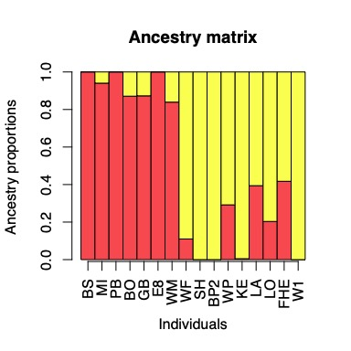

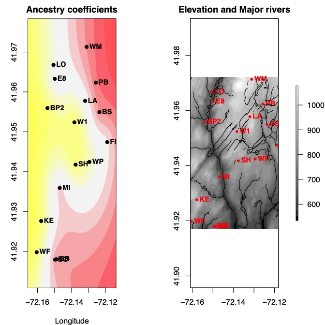

##### 4.3.2 Results when K = 4

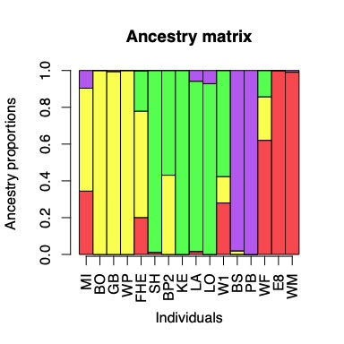

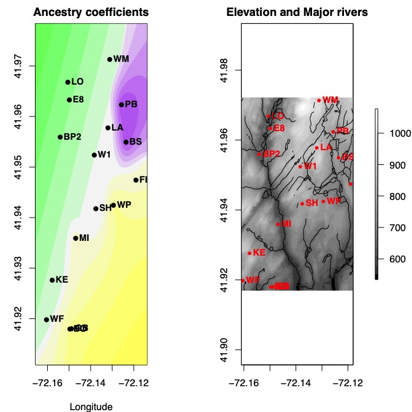

##### 4.3.3 Results when K = 6

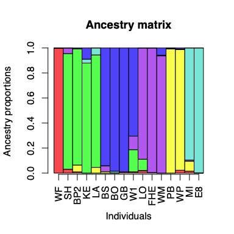

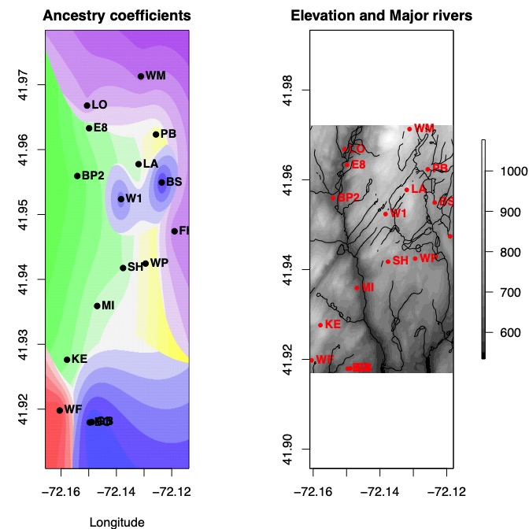

When ancestry assigned at 6, the admixture signature lessened, and more individuals fall into one single ancestry.The ancestry signal due to isolation by resistance from valley and river system is lost. The ancestry needs further variables to explain, which the current model doesn’t capture.

## Discussion

### 5.1 Answers to the two questions set out in the introduction

Because of the stochastic results in the ancestry coefficient due to small sample sizes, the results might not be interpretable. Here is just to demonstrate my work.

**1. how are these 16 unique individuals from 16 populations related to each other by their ancestry (shared allelic frequencies across the genome by inheritance)?**

For the interest of the final project’s hypothesis with the elevation and river systems which separate the area visually by two halves, I assigned the value to K=2. The spatial ancestry interpolation largely conforms to the elevation and river system as the barrier for gene flow (section 4.3.1).

**2. qualitatively, how much correspondence is there between the individuals genetic ancestry to environmental variables, such as elevation and river system (visual interpolations and comparisons)? I hypothesize that the river and elevation would partition the populations into two, due to isolation by resistance.**

The correspondence is strong between the ancestries and the geographic barriers of river and elevation difference (section 4.3.1) when K ancestry assignment is 2. This suggests that these environmental variables can explain overall ancestry. When K increases, as seen in 4.3.2 and 4.3.3, we see the ancestry starts to partition in a way that is not associated with the broad pattern of elevation and geography. Other patterns such as local adaptation might be at play but adaptive loci have been filtered out in my case.

### 5.2 Loading file and running scripts using the Tutorial takes extra steps

To run tess3r and r2vcftools, it requires some development tools and dependencies that configure my computer. The time to create the right environment to run the tutorial scripts is time-consuming. Besides, the tutorial is written for different audiences who look for different methods to apply, so it is like an encyclopedia. I can not simply replicate and run with my data. It takes time to look through the script, pick the chunks that I need and adapt to my circumstance. This also takes a while and sometimes might render some analyses not available.

Lastly, I originally wanted to use the whole dataset (300+ individuals) for the analyses. But each chunk take too long to run, and the developmental stage that requires trial and error would be impossible if I go with the full dataset. So, essential the final project is a complete version of “minimal viability analysis.” Next step would be to run the code with the full dataset.

### 5.3 Very data quality necessitates understanding

Upstream SNPs data filtering is essential for ancestry assignment. We want to build ancestry based on the neutral variation of populations due to gene flow and drift. My collaborator Andis filtered out only missingness and I still needed to the rest of the filtering. Genotype matrix is good for visually examining the heterozygosity of the data across different regions, and whether there is remaining missing data. Site depths determine the trustworthiness of the loci data. Necleotide diversity per site is a good measurement for amount of useful variation for all loci. Hardy Weinberg Equilibrium is good to assess amount of non-neutral variations there are in the SNPs.

### 5.4 Correct SNPs filtering is based on quality check

Meanwhile, we want to filter out the regions that are under selection and physical linkage. So quality check and applying appropriate filtering threshold is critical. It took me a while to carefully look through the methods of each quality check, understand them, and filter my SNPs accordingly. I don’t have a reference number to draw the line of which threshold is good enough, so I’m not sure if I over-filtered or under-filtered. I started out with 18k SNPs, but left with about 3500 SNPs. And the limited number of SNPs also rendered the TESS analyses not accurate (section 5.5).

### 5.5 Ancestry proportion assignment in my research is stochastic, and is K dependent

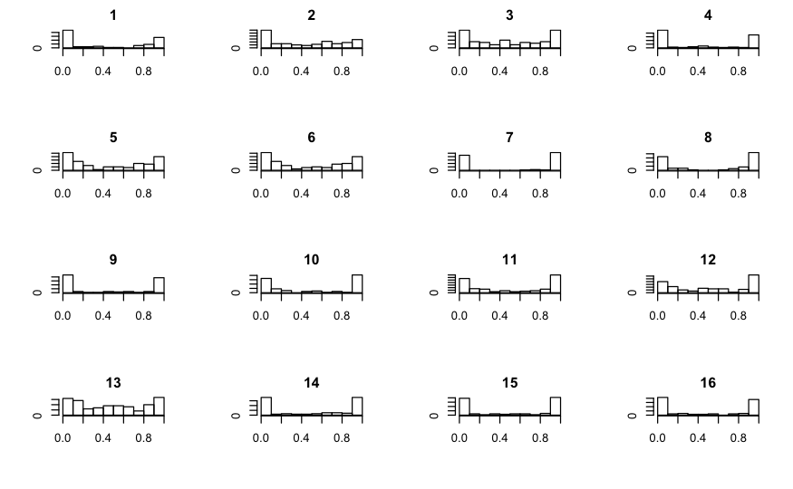

### 5.6 Ancestry mapping is exploratory without testing underlying mechanisms

Spatial Ancestry mapping tells me to which spatial extents the individuals with similar genetic composition dominate the landscape based on the coalescence. The spatial components here only included the coordinates, and the extent of ancestry is limited by nearest neighbor graphs. This excludes the possibility that far-away individuals can be closely related due to ancestry. Also, I didn’t include the environmental heterogeneity into the analyses so I can not test the correlation between elevation + river system and ancestry. Overall, I can not know which factors contributed to the separation of ancestry besides saying that there is a correspondence between elevation/river system and ancestry. Further analyses on landscape resistance by including raster type environmental datasets and associating them with the genotype matrix can test actual relations between genetics and environemnt.

## References

*Background:*  
Freidenburg, L. K., and Skelly, D. K. (2004). Microgeographical variation in thermal preference by an amphibian. Ecol. Lett. 7, 369–373. doi:10.1111/j.1461-0248.2004.00587.x.

Ligon, N. F., and Skelly, D. K. (2009). Cryptic divergence: countergradient variation in the wood frog. Evol. Ecol. Res. 11, 1099–1109. http://www.evolutionary-ecology.com/issues/v11/n07/jjar2510.pdf

Skelly, D. K. (2004). Microgeographic countergradient variation in the wood frog, Rana sylvatica. Evolution 58, 160–165. doi:10.1111/j.0014-3820.2004.tb01582.x.

Richardson, J. L. 2012. Divergent landscape effects on population connectivity in two co-occurring amphibian species: divergent landscape effects on two amphibians. Molecular Ecology 21:4437–4451.

*VCFTOOLS:*  
The Variant Call Format and VCFtools, Petr Danecek, Adam Auton, Goncalo Abecasis, Cornelis A. Albers, Eric Banks, Mark A. DePristo, Robert Handsaker, Gerton Lunter, Gabor Marth, Stephen T. Sherry, Gilean McVean, Richard Durbin and 1000 Genomes Project Analysis Group, Bioinformatics, 2011

*TESS3R:*  
Kevin Caye, Timo Deist, Helena Martins, Olivier Michel, Olivier Francois (2016) TESS3: fast inference of spatial population structure and genome scans for selection. Molecular Ecology Resources 16 (2), 540-548. doi: 10.1111/1755-0998.12471.

Kevin Caye, Flora Jay, Olivier Michel, Olivier Francois. Fast Inference of Individual Admixture Coefficients Using Geographic Data. bioRxiv, 2016, doi: http://dx.doi.org/10.1101/080291